# 14-week

1. 使用 Pandas 网络数据阅读器从雅虎财经获取金融数据

```python
import pandas as pd  # 网络数据阅读器
import datetime
import pandas_datareader.data as web
from pandas import Series, DataFrame
start = datetime.datetime(2021, 5, 27)  # 开始时间
end = datetime.datetime(2022, 5, 26)  # 结束时间
# 从雅虎获取数据，雅虎已经停止向大陆提供服务，需要连接代理使用该方法。
df = web.DataReader("TSLA", 'yahoo', start, end)
```

```python
df.tail()  # tail()方法一般用来对数据集进行矩阵形式的显示，默认显示为数据集的最后5行。
```

| Date | High | Low | Open | Close | Volume | Adj Close |
| --- | --- | --- | --- | --- | --- | --- |
| 2022-05-20 | 721.580017 | 633.000000 | 713.989990 | 663.900024 | 48324400 | 663.900024 |
| 2022-05-23 | 679.960022 | 638.059998 | 655.020020 | 674.900024 | 29634500 | 674.900024 |
| 2022-05-24 | 653.919983 | 620.570007 | 653.530029 | 628.159973 | 29697500 | 628.159973 |
| 2022-05-25 | 669.320007 | 623.010010 | 623.849976 | 658.799988 | 30713100 | 658.799988 |
| 2022-05-26 | 718.669983 | 653.659973 | 661.419983 | 707.729980 | 35334400 | 707.729980 |

1. 观察 df 的数据和结构

[output not shown]

```python
print(df["Adj Close"])
```

```
Date
2021-05-26    619.130005
2021-05-27    630.849976
2021-05-28    625.219971
2021-06-01    623.900024
2021-06-02    605.119995
                 ...
2022-05-20    663.900024
2022-05-23    674.900024
2022-05-24    628.159973
2022-05-25    658.799988
2022-05-26    707.729980
Name: Adj Close, Length: 254, dtype: float64
```

```python
print(df["Adj Close"].describe())
```

```
count     254.000000
mean      857.064052
std       168.881017
min       572.840027
25%       709.757492
50%       841.630005
75%      1008.975006
max      1229.910034
Name: Adj Close, dtype: float64
```

1. 使用 matplotlib 绘制股票市场曲线图

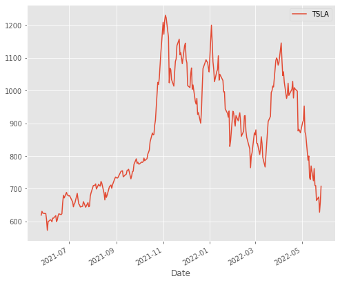

```python
import matplotlib as mpl
from matplotlib import style  # 绘图样式
import matplotlib.pyplot as plt
%matplotlib inline
# 加上 上一行的语句可以不使用第12行的语句就生成图片
mpl.rc("figure", figsize=(8, 7))  # 自定义图形的各种默认属性，8行7列
# mpl.__version__
style.use('ggplot')  # ggplot代表图片主题，橙黄色就是图片的主题色
df["Adj Close"].plot(label="TSLA")  # 标签是TSlA
plt.legend()
#plt.show()
```

1. 生成移动平均值,确定趋势

```python
import pandas_ta  # 这是一个面向股市的库,下方有更详细的介绍。
df.ta.ema(close="Adj Close", length=10, append=True)  # 数据前length长度计算移动平均值
df
```

| Date | High | Low | Open | Close | Volume | Adj Close | EMA_10 |
| --- | --- | --- | --- | --- | --- | --- | --- |
| 2021-05-26 | 626.169983 | 601.500000 | 607.559998 | 619.130005 | 28639300 | 619.130005 | NaN |
| 2021-05-27 | 631.130005 | 616.210022 | 620.239990 | 630.849976 | 26370600 | 630.849976 | NaN |
| 2021-05-28 | 635.590027 | 622.380005 | 628.500000 | 625.219971 | 22737000 | 625.219971 | NaN |
| 2021-06-01 | 633.799988 | 620.549988 | 627.799988 | 623.900024 | 18084900 | 623.900024 | NaN |
| 2021-06-02 | 623.359985 | 599.140015 | 620.130005 | 605.119995 | 23302800 | 605.119995 | NaN |
| ... | ... | ... | ... | ... | ... | ... | ... |
| 2022-05-20 | 721.580017 | 633.000000 | 713.989990 | 663.900024 | 48324400 | 663.900024 | 746.346567 |
| 2022-05-23 | 679.960022 | 638.059998 | 655.020020 | 674.900024 | 29634500 | 674.900024 | 733.356286 |
| 2022-05-24 | 653.919983 | 620.570007 | 653.530029 | 628.159973 | 29697500 | 628.159973 | 714.229684 |
| 2022-05-25 | 669.320007 | 623.010010 | 623.849976 | 658.799988 | 30713100 | 658.799988 | 704.151557 |
| 2022-05-26 | 718.669983 | 653.659973 | 661.419983 | 707.729980 | 35334400 | 707.729980 | 704.802180 |

254 rows × 7 columns

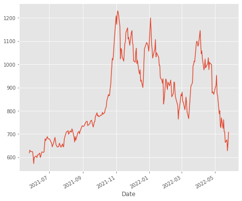

```python
#print(df["Adj Close"])  # 便于查看
df["Adj Close"].plot(label="TSLA")  # 用Adj Close那列数据进行画图
```

1. 计算回报偏差

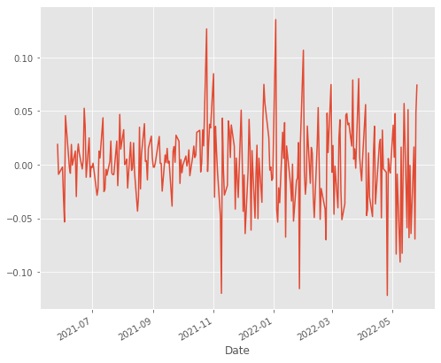

```python
df["Return"] = df["Adj Close"]/df["Adj Close"].shift(1)-1
#shift(1)将数据下降一次
df["Return"].plot(label='return')
plt.show()
```

1. 删除前 10 行数据

```python
# iloc函数，属于pands库，全称为index location，即对数据进行位置（location）索引（index）。
df = df.iloc[10:]
```

```python
df.head(10)  # 输出头10个数据
```

| Date | High | Low | Open | Close | Volume | Adj Close | EMA_10 | Return |
| --- | --- | --- | --- | --- | --- | --- | --- | --- |
| 2021-06-10 | 616.590027 | 600.500000 | 603.880005 | 610.119995 | 23919600 | 610.119995 | 608.680821 | 0.018938 |
| 2021-06-11 | 612.559998 | 601.520020 | 610.229980 | 609.890015 | 16205300 | 609.890015 | 608.900674 | -0.000377 |
| 2021-06-14 | 625.489990 | 609.179993 | 612.229980 | 617.690002 | 20424000 | 617.690002 | 610.498734 | 0.012789 |
| 2021-06-15 | 616.789978 | 598.229980 | 616.690002 | 599.359985 | 17764100 | 599.359985 | 608.473507 | -0.029675 |
| 2021-06-16 | 608.500000 | 593.500000 | 597.539978 | 604.869995 | 22144100 | 604.869995 | 607.818323 | 0.009193 |
| 2021-06-17 | 621.469971 | 601.340027 | 601.890015 | 616.599976 | 22701400 | 616.599976 | 609.414987 | 0.019393 |
| 2021-06-18 | 628.349976 | 611.799988 | 613.369995 | 623.309998 | 24560900 | 623.309998 | 611.941353 | 0.010882 |
| 2021-06-21 | 631.390015 | 608.880005 | 624.479980 | 620.830017 | 24812700 | 620.830017 | 613.557473 | -0.003979 |
| 2021-06-22 | 628.570007 | 615.500000 | 618.250000 | 623.710022 | 19158900 | 623.710022 | 615.403391 | 0.004639 |
| 2021-06-23 | 657.200012 | 630.039978 | 632.000000 | 656.570007 | 31099200 | 656.570007 | 622.888231 | 0.052685 |

1. 最高价和最低价百分比

```python
df_reg = df.loc[:, ['Adj Close', 'EMA_10', "Return"]]
# 参数1：利用切片遍历所有标签(从high开始，到Return结束)
# 参数2：以列表的形式对df数据操作，保留列表内的标签数据
df_reg["HL_PCT"] = (df['High']-df["Low"])/df["Close"]*100.0
```

```python
df_reg
```

| Date | Adj Close | EMA_10 | Return | HL_PCT |
| --- | --- | --- | --- | --- |
| 2021-06-10 | 610.119995 | 608.680821 | 0.018938 | 2.637191 |
| 2021-06-11 | 609.890015 | 608.900674 | -0.000377 | 1.810159 |
| 2021-06-14 | 617.690002 | 610.498734 | 0.012789 | 2.640483 |
| 2021-06-15 | 599.359985 | 608.473507 | -0.029675 | 3.096636 |
| 2021-06-16 | 604.869995 | 607.818323 | 0.009193 | 2.479872 |
| ... | ... | ... | ... | ... |
| 2022-05-20 | 663.900024 | 746.346567 | -0.064165 | 13.342373 |
| 2022-05-23 | 674.900024 | 733.356286 | 0.016569 | 6.208331 |
| 2022-05-24 | 628.159973 | 714.229684 | -0.069255 | 5.309153 |
| 2022-05-25 | 658.799988 | 704.151557 | 0.048777 | 7.029447 |
| 2022-05-26 | 707.729980 | 704.802180 | 0.074271 | 9.185708 |

244 rows × 4 columns

1. 计算收盘变化率

```python
df_reg["PCT_change"] = (df['Close']-df["Open"])/df["Open"]*100.0
```

```python
df_reg
```

| Date | Adj Close | EMA_10 | Return | HL_PCT | PCT_change |
| --- | --- | --- | --- | --- | --- |
| 2021-06-10 | 610.119995 | 608.680821 | 0.018938 | 2.637191 | 1.033316 |
| 2021-06-11 | 609.890015 | 608.900674 | -0.000377 | 1.810159 | -0.055711 |
| 2021-06-14 | 617.690002 | 610.498734 | 0.012789 | 2.640483 | 0.891825 |
| 2021-06-15 | 599.359985 | 608.473507 | -0.029675 | 3.096636 | -2.810167 |
| 2021-06-16 | 604.869995 | 607.818323 | 0.009193 | 2.479872 | 1.226699 |
| ... | ... | ... | ... | ... | ... |
| 2022-05-20 | 663.900024 | 746.346567 | -0.064165 | 13.342373 | -7.015500 |
| 2022-05-23 | 674.900024 | 733.356286 | 0.016569 | 6.208331 | 3.035022 |
| 2022-05-24 | 628.159973 | 714.229684 | -0.069255 | 5.309153 | -3.882003 |
| 2022-05-25 | 658.799988 | 704.151557 | 0.048777 | 7.029447 | 5.602310 |
| 2022-05-26 | 707.729980 | 704.802180 | 0.074271 | 9.185708 | 7.001602 |

244 rows × 5 columns

1. 预处理
- 在将数据放⼊预测模型之前，我们将对数据进⾏标准化，使每个样本都可以具有相同的线性回归分布。

```python
from sklearn.preprocessing import scale
import math
import numpy as np
```

```python
X = np.array(df_reg.drop(["EMA_10"],1))#去掉标签：EMA_10 生成数据子集
# 将ema_10这⼀列去掉，剩余的作为训练数据x
```

```python
print(X)
```

```
[[ 6.10119995e+02  1.89384503e-02  2.63719055e+00  1.03331625e+00]
 [ 6.09890015e+02 -3.76943012e-04  1.81015884e+00 -5.57110977e-02]
 [ 6.17690002e+02  1.27891712e-02  2.64048268e+00  8.91825318e-01]
 [ 5.99359985e+02 -2.96751073e-02  3.09663608e+00 -2.81016670e+00]
 [ 6.04869995e+02  9.19315587e-03  2.47987173e+00  1.22669903e+00]
 [ 6.16599976e+02  1.93925646e-02  3.26466828e+00  2.44396162e+00]
 [ 6.23309998e+02  1.08822936e-02  2.65517766e+00  1.62055570e+00]
 [ 6.20830017e+02 -3.97872724e-03  3.62579275e+00 -5.84480447e-01]
 [ 6.23710022e+02  4.63895882e-03  2.09552626e+00  8.83141443e-01]
 [ 6.56570007e+02  5.26847160e-02  4.13665472e+00  3.88765939e+00]
 [ 6.79820007e+02  3.54113038e-02  4.41440520e+00  7.15568699e-01]
 [ 6.71869995e+02 -1.16942898e-02  3.73732799e+00 -2.56823306e+00]
 [ 6.88719971e+02  2.50792202e-02  3.53990096e+00  2.54302241e+00]
 [ 6.80760010e+02 -1.15576160e-02  1.70691506e+00 -5.68175639e-01]
 [ 6.79700012e+02 -1.55707965e-03  2.15830258e+00 -1.02986778e-02]
 [ 6.77919983e+02 -2.61884547e-03  2.24067778e+00 -8.77295612e-01]
 [ 6.78900024e+02  1.44565956e-03  3.93872283e+00 -1.17759075e-02]
 [ 6.59580017e+02 -2.84578091e-02  4.94253536e+00 -3.24624902e+00]
 [ 6.44650024e+02 -2.26356049e-02  4.24726655e+00 -2.95361744e+00]
 [ 6.52809998e+02  1.26579894e-02  5.20365356e+00  3.88942862e+00]
 [ 6.56950012e+02  6.34183708e-03  2.16454379e+00  5.77179273e-01]
 [ 6.85700012e+02  4.37628426e-02  3.65757863e+00  3.54877674e+00]
 [ 6.68539978e+02 -2.50255708e-02  4.03566614e+00 -2.59063252e+00]
 [ 6.53380005e+02 -2.26762402e-02  3.94409965e+00 -2.58963774e+00]
 [ 6.50599976e+02 -4.25484293e-03  4.34368442e+00 -1.18319520e+00]
 [ 6.44219971e+02 -9.80634049e-03  2.25078400e+00 -1.59773051e+00]
 [ 6.46219971e+02  3.10452965e-03  4.00947593e+00  2.59250912e+00]
 [ 6.60500000e+02  2.20977840e-02  3.31415816e+00  1.30523626e+00]
 [ 6.55289978e+02 -7.88799693e-03  2.22344425e+00 -6.54933585e-01]
 [ 6.49260010e+02 -9.20198456e-03  2.70615887e+00 -1.09377744e+00]
 [ 6.43380005e+02 -9.05647167e-03  1.78743509e+00 -4.61040370e-01]
 [ 6.57619995e+02  2.21330942e-02  3.20702336e+00  1.02155625e+00]
 [ 6.44780029e+02 -1.95249018e-02  6.08889978e+00 -2.80675225e+00]
 [ 6.46979980e+02  3.41194062e-03  2.40655766e+00 -3.09420885e-03]
 [ 6.77349976e+02  4.69411667e-02  5.15095828e+00  4.24137006e+00]
 [ 6.87200012e+02  1.45420196e-02  4.15163399e+00  2.29844025e+00]
 [ 7.09669983e+02  3.26978613e-02  4.02158450e+00  1.38142613e+00]
 [ 7.09739990e+02  9.86477178e-05  3.04900597e+00 -1.28790122e+00]
 [ 7.10919983e+02  1.66257037e-03  2.24638948e+00 -1.12541617e-02]
 [ 7.14630005e+02  5.21862103e-03  1.33496201e+00 -1.91340100e-01]
```

[output cut: 189 more lines]

```
 [ 8.65650024e+02 -8.73718009e-03  5.18570015e+00 -2.40698710e+00]
 [ 7.87109985e+02 -9.07295522e-02  8.19199117e+00 -5.89874184e+00]
 [ 8.00039978e+02  1.64271740e-02  6.38842892e+00 -2.35198150e+00]
 [ 7.34000000e+02 -8.25458475e-02  1.12493198e+01 -7.67295597e+00]
 [ 7.28000000e+02 -8.17438692e-03  1.09423040e+01  3.85164051e+00]
 [ 7.69590027e+02  5.71291578e-02  4.64922452e+00 -5.02915875e-01]
 [ 7.24369995e+02 -5.87585989e-02  6.99504166e+00 -5.57771254e+00]
 [ 7.61609985e+02  5.14101778e-02  4.67824813e+00  1.90671166e+00]
 [ 7.09809998e+02 -6.80137981e-02  8.40929300e+00 -4.66206698e+00]
 [ 7.09419983e+02 -5.49463448e-04  5.62290542e+00  3.42288955e-01]
 [ 6.63900024e+02 -6.41650357e-02  1.33423729e+01 -7.01549973e+00]
 [ 6.74900024e+02  1.65687597e-02  6.20833055e+00  3.03502249e+00]
 [ 6.28159973e+02 -6.92547779e-02  5.30915324e+00 -3.88200312e+00]
 [ 6.58799988e+02  4.87774070e-02  7.02944724e+00  5.60231042e+00]
 [ 7.07729980e+02  7.42713928e-02  9.18570805e+00  7.00160242e+00]]
```

```python
X = scale(X)
# 对x进⾏标准化 (X-mean)/std
```

```python
print(X)
```

```
[[-1.56711656e+00  4.74405873e-01 -7.97037271e-01  3.15104173e-01]
 [-1.56851818e+00 -4.72773555e-02 -1.12225912e+00 -7.80390186e-03]
 [-1.52098126e+00  3.08321976e-01 -7.95742673e-01  2.73150622e-01]
 [-1.63269329e+00 -8.38582025e-01 -6.16364968e-01 -8.24528989e-01]
 [-1.59911261e+00  2.11198359e-01 -8.58901305e-01  3.72444202e-01]
 [-1.52762442e+00  4.86670900e-01 -5.50288005e-01  7.33375377e-01]
 [-1.48673028e+00  2.56819735e-01 -7.89964023e-01  4.89226854e-01]
 [-1.50184449e+00 -1.44556784e-01 -4.08279465e-01 -1.64589581e-01]
 [-1.48429234e+00  8.81955194e-02 -1.01004127e+00  2.70575761e-01]
 [-1.28402763e+00  1.38584788e+00 -2.07388170e-01  1.16144697e+00]
 [-1.14233084e+00  9.19315861e-01 -9.81656043e-02  2.20888678e-01]
 [-1.19078208e+00 -3.52943926e-01 -3.64419364e-01 -7.52793117e-01]
 [-1.08809014e+00  6.40259948e-01 -4.42055541e-01  7.62747943e-01]
 [-1.13660201e+00 -3.49252546e-01 -1.16285869e+00 -1.59755034e-01]
 [-1.14306215e+00 -7.91512854e-02 -9.85355116e-01  5.66135876e-03]
 [-1.15391051e+00 -1.07828176e-01 -9.52961902e-01 -2.51412361e-01]
 [-1.14793766e+00  1.94872959e-03 -2.85222882e-01  5.22334459e-03]
 [-1.26568317e+00 -8.05704413e-01  1.09516234e-01 -9.53831987e-01]
 [-1.35667380e+00 -6.48454376e-01 -1.63891185e-01 -8.67063642e-01]
 [-1.30694296e+00  3.04778929e-01  2.12198323e-01  1.16197156e+00]
 [-1.28171170e+00  1.34188009e-01 -9.82900823e-01  1.79854756e-01]
 [-1.10649524e+00  1.14487988e+00 -3.95779992e-01  1.06096469e+00]
 [-1.21107682e+00 -7.13004193e-01 -2.47100907e-01 -7.59434793e-01]
 [-1.30346906e+00 -6.49551882e-01 -2.83108500e-01 -7.59139829e-01]
 [-1.32041190e+00 -1.52014304e-01 -1.25975836e-01 -3.42114810e-01]
 [-1.35929475e+00 -3.01952911e-01 -9.48987736e-01 -4.65028893e-01]
 [-1.34710578e+00  4.67526169e-02 -2.57399940e-01  7.77421274e-01]
 [-1.26007635e+00  5.59735297e-01 -5.30826613e-01  3.95731319e-01]
 [-1.29182875e+00 -2.50140988e-01 -9.59738815e-01 -1.85479678e-01]
 [-1.32857831e+00 -2.85630057e-01 -7.69916179e-01 -3.15601503e-01]
 [-1.36441391e+00 -2.81699946e-01 -1.13119500e+00 -1.27988299e-01]
 [-1.27762850e+00  5.60688979e-01 -5.72956289e-01  3.11617209e-01]
 [-1.35588148e+00 -5.64438399e-01  5.60312433e-01 -8.23516569e-01]
 [-1.34247391e+00  5.50553806e-02 -8.87731319e-01  7.79755966e-03]
 [-1.15738441e+00  1.23072221e+00  1.91476436e-01  1.26632590e+00]
 [-1.09735351e+00  3.55664094e-01 -2.01497722e-01  6.90226759e-01]
 [-9.60410593e-01  8.46029368e-01 -2.52638368e-01  4.18322417e-01]
 [-9.59983935e-01 -3.44322788e-02 -6.35095028e-01 -3.73161246e-01]
 [-9.52792486e-01  7.80720362e-03 -9.50715833e-01  5.37804772e-03]
 [-9.30181811e-01  1.03851429e-01 -1.30912546e+00 -4.80193291e-02]
```

[output cut: 189 more lines]

```
 [-9.79247174e-03 -2.73076302e-01  2.05138326e-01 -7.04981993e-01]
 [-4.88453611e-01 -2.48758184e+00  1.38733183e+00 -1.74032404e+00]
 [-4.09651957e-01  4.06579621e-01  6.78099236e-01 -6.88672252e-01]
 [-8.12131654e-01 -2.26655080e+00  2.58959536e+00 -2.26639721e+00]
 [-8.48698568e-01 -2.57876003e-01  2.46886450e+00  1.15076699e+00]
 [-5.95228747e-01  1.50588637e+00 -5.82528344e-03 -1.40404827e-01]
 [-8.70821580e-01 -1.62408867e+00  9.16643552e-01 -1.64513547e+00]
 [-6.43862995e-01  1.35142429e+00  5.58795504e-03  5.74075108e-01]
 [-9.59557276e-01 -1.87405936e+00  1.47278357e+00 -1.37363692e+00]
 [-9.61934215e-01 -5.19369043e-02  3.77064869e-01  1.10207304e-01]
 [-1.23935495e+00 -1.77010938e+00  3.41266730e+00 -2.07145451e+00]
 [-1.17231561e+00  4.10403665e-01  6.07277376e-01  9.08631147e-01]
 [-1.45717218e+00 -1.90757658e+00  2.53685003e-01 -1.14233977e+00]
 [-1.27043705e+00  1.28031663e+00  9.30173199e-01  1.66985905e+00]
 [-9.72233911e-01  1.96887547e+00  1.77810093e+00  2.08476386e+00]]
```

```python
Y = np.array(df_reg['EMA_10'])
```

```python
print(Y)
```

```
[ 608.68082109  608.90067446  610.4987341   608.47350705  607.81832306
  609.41498716  611.94135269  613.55747349  615.40339139  622.88823065
  633.23946278  640.26319593  649.07351861  654.83469882  659.35566489
  662.73099544  665.67081889  664.56340038  660.94278657  659.46409766
  659.00699121  663.86026776  664.71112417  662.65092066  660.45983974
  657.50713628  655.45492436  656.37221084  656.17544124  654.91809006
  652.82025639  653.69293616  652.07240764  651.14651179  655.91077793
  661.59972962  670.33977567  677.50345105  683.57918411  689.22478789
  691.02027656  695.15477351  697.85208564  699.66443504  703.77090139
  706.20709803  702.56398619  695.86326543  694.61357903  690.7692866
  688.858509    692.02968696  695.02246937  697.9638408   698.54495577
  700.97677889  706.41917784  711.74659473  715.80903693  718.82376015
  721.504896    727.21672999  732.06277819  736.20772495  736.21905124
  737.45195101  738.73159451  741.84039861  744.59486982  747.30307353
  744.18796614  743.31379137  744.88219338  746.47452452  751.55006818
  758.78823494  762.20128269  765.67559448  767.45821012  768.86943931
  771.17136477  772.88384878  774.67769446  778.11992917  779.45994027
  781.72904248  786.09102943  790.63448173  795.66821366  804.27945287
  816.24864059  824.9798004   832.40165265  843.60135217  855.61565044
  886.3873477   910.39510133  933.57053479  959.6558992   987.71846298
 1027.87691805 1054.08111476 1083.13181851 1109.81876681 1130.23171209
 1136.17866287 1115.69163326 1107.01132742 1099.10199694 1087.15982367
 1073.74713112 1070.28946737 1073.69320235 1077.81807554 1088.58934518
 1101.00400881 1102.46328526 1104.92450612 1100.74187663 1107.33244274
 1114.13745493 1110.65791767 1105.92011002 1089.38372105 1074.770319
 1070.58480645 1070.28938    1058.2003996  1050.71487772 1035.38671325
 1021.4091308  1013.15110524  997.47271937  985.67222627  970.08454921
  964.34736377  972.44238765  989.63468081 1008.59927364 1023.12121856
 1034.58825908 1041.0885694  1043.94156211 1072.27582887 1086.33294468
 1086.65786294 1082.66551534 1072.53723273 1069.9159168  1068.91302727
 1075.6961079  1067.67137166 1064.38748324 1058.22794261 1046.8501393
 1037.65375389 1020.60762126 1004.1335083   988.54560214  979.24821505
  951.94853515  932.74879704  933.47082862  933.0670416   928.08393824
  921.36686123  921.7219787   919.10707836  919.63306412  921.88159791
  918.73039607  908.05214224  902.18084543  905.86250856  909.04932785
  903.10399108  894.71780733  881.4109386   860.07076395  849.28881042
  842.12175309  847.26870574  850.37803108  855.74384628  852.75223387
  850.12273281  841.84223904  838.67092729  842.36166246  841.62317615
  833.20986696  821.05716299  817.57222693  821.69181848  830.76602886
  844.33402628  858.30238025  882.97103484  904.08720766  924.05680316
  939.79920525  967.4429799   991.4660647  1010.10677843 1022.37826882
 1033.68948646 1054.00957095 1060.78237801 1058.05103833 1057.90721495
 1052.0131741  1038.17986838 1028.86534908 1027.68437563 1019.92358006
 1017.08110696 1019.09363741 1011.47661465 1010.9863264  1009.90699211
 1007.74572437  983.86831683  965.25771554  949.30358722  935.02293677
  929.18967599  925.56428035  930.48350122  920.08286996  910.18598895
  887.80853375  871.85061453  846.78686643  825.18925435  815.0803039
  798.58752048  791.86433228  776.94536233  764.66802062  746.34656676
  733.35628634  714.22968394  704.15155737  704.80217975]
```

```python
X_lately = X[-10:]  # 倒数十条数据
X = X[:-10]  # 除去后十条的数据
Y = Y[:-10]  # 除去后十条的数据
```

```python
print(X[:5])
print(X.shape)
print(Y.shape)
```

```
[[-1.56711656  0.47440587 -0.79703727  0.31510417]
 [-1.56851818 -0.04727736 -1.12225912 -0.0078039 ]
 [-1.52098126  0.30832198 -0.79574267  0.27315062]
 [-1.63269329 -0.83858203 -0.61636497 -0.82452899]
 [-1.59911261  0.21119836 -0.85890131  0.3724442 ]]
(234, 4)
(234,)
```

1. 模型训练

```python
from sklearn.linear_model import LinearRegression  # LinearRegression ————> 线性回归
from sklearn.neighbors import KNeighborsRegressor # KNeighborsRegressor ————> k近邻回归
from sklearn.pipeline import make_pipeline
from sklearn.model_selection import train_test_split  # 训练集和测试集的划分
```

```python
X_train, X_test, Y_train, Y_test = train_test_split(
    X, Y, test_size=.2, random_state=2022)
```

- 进行线性回归

```python
clfreg = LinearRegression(n_jobs=-1)  # n_jobs表示启动设备cpu的核心个数,-1表示启动所有的核心
clfreg.fit(X_train, Y_train)  # 训练
confidencereg = clfreg.score(X_test, Y_test)  # 利用测试集进行评估
```

```python
print('线性回归模型决定系数为 ', confidencereg)
```

```
线性回归模型决定系数为  0.9607696648538135
```

```python
forecast_set = clfreg.predict(X_lately)  # 进行预测
df_reg["Forecast"] = np.nan  # 建立全是NaN的列表,用来给后面更新
```

```python
print(forecast_set.shape)
```

```
(10,)
```

```python
df_reg  # 应该是print(df_reg)
```

| Date | Adj Close | EMA_10 | Return | HL_PCT | PCT_change | Forecast |
| --- | --- | --- | --- | --- | --- | --- |
| 2021-06-10 | 610.119995 | 608.680821 | 0.018938 | 2.637191 | 1.033316 | NaN |
| 2021-06-11 | 609.890015 | 608.900674 | -0.000377 | 1.810159 | -0.055711 | NaN |
| 2021-06-14 | 617.690002 | 610.498734 | 0.012789 | 2.640483 | 0.891825 | NaN |
| 2021-06-15 | 599.359985 | 608.473507 | -0.029675 | 3.096636 | -2.810167 | NaN |
| 2021-06-16 | 604.869995 | 607.818323 | 0.009193 | 2.479872 | 1.226699 | NaN |
| ... | ... | ... | ... | ... | ... | ... |
| 2022-05-20 | 663.900024 | 746.346567 | -0.064165 | 13.342373 | -7.015500 | NaN |
| 2022-05-23 | 674.900024 | 733.356286 | 0.016569 | 6.208331 | 3.035022 | NaN |
| 2022-05-24 | 628.159973 | 714.229684 | -0.069255 | 5.309153 | -3.882003 | NaN |
| 2022-05-25 | 658.799988 | 704.151557 | 0.048777 | 7.029447 | 5.602310 | NaN |
| 2022-05-26 | 707.729980 | 704.802180 | 0.074271 | 9.185708 | 7.001602 | NaN |

244 rows × 6 columns

```python
last_date = df_reg.iloc[-1].name  # 索引最后一行数据的行标题
```

```python
print(last_date)
```

```
2022-05-26 00:00:00
```

```python
last_unix = last_date
next_unix = last_unix + datetime.timedelta(days=1)  # 数学里面的Δ,变化days=1为一天
```

```python
print(next_unix)
```

```
2022-05-27 00:00:00
```

```python
for i in forecast_set:
    next_date = next_unix
    next_unix+=datetime.timedelta(days = 1)
    df_reg.loc[next_date] = [np.nan for _ in range(len(df_reg.columns)-1)]+[i]
    print(df_reg.loc[next_date])
```

```
Adj Close            NaN
EMA_10               NaN
Return               NaN
HL_PCT               NaN
PCT_change           NaN
Forecast      733.291745
Name: 2022-05-27 00:00:00, dtype: float64
Adj Close            NaN
EMA_10               NaN
Return               NaN
HL_PCT               NaN
PCT_change           NaN
Forecast      792.563413
Name: 2022-05-28 00:00:00, dtype: float64
Adj Close            NaN
EMA_10               NaN
Return               NaN
HL_PCT               NaN
PCT_change           NaN
Forecast      734.290051
Name: 2022-05-29 00:00:00, dtype: float64
Adj Close            NaN
EMA_10               NaN
Return               NaN
HL_PCT               NaN
PCT_change           NaN
Forecast      797.872917
Name: 2022-05-30 00:00:00, dtype: float64
Adj Close            NaN
EMA_10               NaN
Return               NaN
HL_PCT               NaN
PCT_change           NaN
Forecast      732.766092
Name: 2022-05-31 00:00:00, dtype: float64
Adj Close            NaN
EMA_10               NaN
Return               NaN
HL_PCT               NaN
PCT_change           NaN
```

[output cut: 15 more lines]

```
Name: 2022-06-03 00:00:00, dtype: float64
Adj Close           NaN
EMA_10              NaN
Return              NaN
HL_PCT              NaN
PCT_change          NaN
Forecast      666.35815
Name: 2022-06-04 00:00:00, dtype: float64
Adj Close            NaN
EMA_10               NaN
Return               NaN
HL_PCT               NaN
PCT_change           NaN
Forecast      706.743255
Name: 2022-06-05 00:00:00, dtype: float64
```

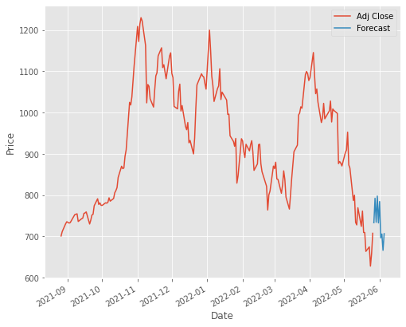

```python
df_reg["Adj Close"].tail(200).plot()
df_reg['Forecast'].tail(200).plot()
plt.legend()
plt.xlabel('Date')
plt.ylabel('Price')
plt.show()
```

# 作业

```python
import pandas_datareader as web
import datetime

start = datetime.datetime(2020,1,1)
end = datetime.datetime(2022,1,1)
data = web.DataReader('AAPL',"yahoo",start,end)
```

```python
data
```

| Date | High | Low | Open | Close | Volume | Adj Close |
| --- | --- | --- | --- | --- | --- | --- |
| 2019-12-31 | 73.419998 | 72.379997 | 72.482498 | 73.412498 | 100805600.0 | 72.139946 |
| 2020-01-02 | 75.150002 | 73.797501 | 74.059998 | 75.087502 | 135480400.0 | 73.785912 |
| 2020-01-03 | 75.144997 | 74.125000 | 74.287498 | 74.357498 | 146322800.0 | 73.068565 |
| 2020-01-06 | 74.989998 | 73.187500 | 73.447502 | 74.949997 | 118387200.0 | 73.650787 |
| 2020-01-07 | 75.224998 | 74.370003 | 74.959999 | 74.597504 | 108872000.0 | 73.304413 |
| ... | ... | ... | ... | ... | ... | ... |
| 2021-12-27 | 180.419998 | 177.070007 | 177.089996 | 180.330002 | 74919600.0 | 179.836319 |
| 2021-12-28 | 181.330002 | 178.529999 | 180.160004 | 179.289993 | 79144300.0 | 178.799149 |
| 2021-12-29 | 180.630005 | 178.139999 | 179.330002 | 179.380005 | 62348900.0 | 178.888916 |
| 2021-12-30 | 180.570007 | 178.089996 | 179.470001 | 178.199997 | 59773000.0 | 177.712143 |
| 2021-12-31 | 179.229996 | 177.259995 | 178.089996 | 177.570007 | 64062300.0 | 177.083878 |

506 rows × 6 columns

```python
mean = data["Adj Close"].mean()
std = data["Adj Close"].std()
```

```python
print(mean,"|",std)
```

```
117.080503787919 | 29.643263790453
```

```python
import pandas_ta
data.ta.ema(close="Adj Close",length = 100,append = True)
```

```
Date
2019-12-31           NaN
2020-01-02           NaN
2020-01-03           NaN
2020-01-06           NaN
2020-01-07           NaN
                 ...
2021-12-27    154.450624
2021-12-28    154.932773
2021-12-29    155.407152
2021-12-30    155.848835
2021-12-31    156.269331
Name: EMA_100, Length: 506, dtype: float64
```

```python
data
```

| Date | High | Low | Open | Close | Volume | Adj Close | EMA_100 |
| --- | --- | --- | --- | --- | --- | --- | --- |
| 2019-12-31 | 73.419998 | 72.379997 | 72.482498 | 73.412498 | 100805600.0 | 72.139946 | NaN |
| 2020-01-02 | 75.150002 | 73.797501 | 74.059998 | 75.087502 | 135480400.0 | 73.785912 | NaN |
| 2020-01-03 | 75.144997 | 74.125000 | 74.287498 | 74.357498 | 146322800.0 | 73.068565 | NaN |
| 2020-01-06 | 74.989998 | 73.187500 | 73.447502 | 74.949997 | 118387200.0 | 73.650787 | NaN |
| 2020-01-07 | 75.224998 | 74.370003 | 74.959999 | 74.597504 | 108872000.0 | 73.304413 | NaN |
| ... | ... | ... | ... | ... | ... | ... | ... |
| 2021-12-27 | 180.419998 | 177.070007 | 177.089996 | 180.330002 | 74919600.0 | 179.836319 | 154.450624 |
| 2021-12-28 | 181.330002 | 178.529999 | 180.160004 | 179.289993 | 79144300.0 | 178.799149 | 154.932773 |
| 2021-12-29 | 180.630005 | 178.139999 | 179.330002 | 179.380005 | 62348900.0 | 178.888916 | 155.407152 |
| 2021-12-30 | 180.570007 | 178.089996 | 179.470001 | 178.199997 | 59773000.0 | 177.712143 | 155.848835 |
| 2021-12-31 | 179.229996 | 177.259995 | 178.089996 | 177.570007 | 64062300.0 | 177.083878 | 156.269331 |

506 rows × 7 columns

```python
data
```

| Date | High | Low | Open | Close | Volume | Adj Close | EMA_100 |
| --- | --- | --- | --- | --- | --- | --- | --- |
| 2019-12-31 | 73.419998 | 72.379997 | 72.482498 | 73.412498 | 100805600.0 | 72.139946 | NaN |
| 2020-01-02 | 75.150002 | 73.797501 | 74.059998 | 75.087502 | 135480400.0 | 73.785912 | NaN |
| 2020-01-03 | 75.144997 | 74.125000 | 74.287498 | 74.357498 | 146322800.0 | 73.068565 | NaN |
| 2020-01-06 | 74.989998 | 73.187500 | 73.447502 | 74.949997 | 118387200.0 | 73.650787 | NaN |
| 2020-01-07 | 75.224998 | 74.370003 | 74.959999 | 74.597504 | 108872000.0 | 73.304413 | NaN |
| ... | ... | ... | ... | ... | ... | ... | ... |
| 2021-12-27 | 180.419998 | 177.070007 | 177.089996 | 180.330002 | 74919600.0 | 179.836319 | 154.450624 |
| 2021-12-28 | 181.330002 | 178.529999 | 180.160004 | 179.289993 | 79144300.0 | 178.799149 | 154.932773 |
| 2021-12-29 | 180.630005 | 178.139999 | 179.330002 | 179.380005 | 62348900.0 | 178.888916 | 155.407152 |
| 2021-12-30 | 180.570007 | 178.089996 | 179.470001 | 178.199997 | 59773000.0 | 177.712143 | 155.848835 |
| 2021-12-31 | 179.229996 | 177.259995 | 178.089996 | 177.570007 | 64062300.0 | 177.083878 | 156.269331 |

506 rows × 7 columns

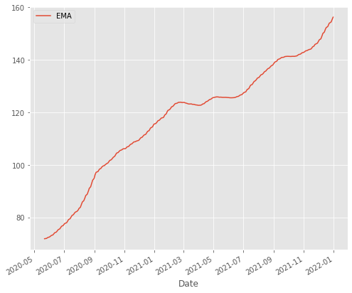

```python
import matplotlib as mpl
import matplotlib.pyplot as plt
mpl.rc("figure", figsize=(8, 7))
data["EMA_100"].plot(label="EMA")
plt.legend()
#plt.savefig('EMA_100')
plt.show()
```

```python
from sklearn.linear_model import LinearRegression  # LinearRegression ————> 线性回归
# KNeighborsRegressor ————> k近邻回归
from sklearn.neighbors import KNeighborsRegressor
from sklearn.pipeline import make_pipeline
from sklearn.model_selection import train_test_split  # 训练集和测试集的划分

import numpy as np
```

```python
data = data.iloc[100:]
datareg = data.loc[:,["Adj Close","EMA_100"]]
x = np.array(datareg.drop(["EMA_100"],1))
```

```python
print(x)
```

```
[[ 78.20572662]
 [ 78.54646301]
 [ 78.58103943]
 [ 78.50450134]
 [ 79.46994019]
 [ 79.83784485]
 [ 80.27734375]
 [ 79.58599091]
 [ 81.85267639]
 [ 82.3366394 ]
 [ 84.93666077]
 [ 87.12185669]
 [ 82.9391098 ]
 [ 83.655159  ]
 [ 84.68973541]
 [ 86.93421173]
 [ 86.81321716]
 [ 86.84779358]
 [ 86.35148621]
 [ 88.61076355]
 [ 90.50215149]
 [ 88.90460205]
 [ 90.08486176]
 [ 87.31694031]
 [ 89.3292923 ]
 [ 90.07497406]
 [ 89.90460205]
 [ 89.90460205]
 [ 92.30957031]
 [ 92.02315521]
 [ 94.16637421]
 [ 94.57132721]
 [ 94.736763  ]
 [ 94.29972076]
 [ 95.86023712]
 [ 96.5194931 ]
 [ 95.33183289]
 [ 95.13922882]
 [ 97.1441803 ]
 [ 95.80342865]
```

[output cut: 351 more lines]

```
 [178.95872498]
 [175.25888062]
 [173.85275269]
 [178.80914307]
 [171.78840637]
 [170.67147827]
 [169.28527832]
 [172.5164032 ]
 [175.15914917]
 [175.79740906]
 [179.83631897]
 [178.79914856]
 [178.88891602]
 [177.71214294]
 [177.08387756]]
```

```python
from sklearn.preprocessing import scale
x = scale(x)
```

```python
x
```

```
array([[-2.34743821e+00],
       [-2.33144732e+00],
       [-2.32982463e+00],
       [-2.33341659e+00],
       [-2.28810816e+00],
       [-2.27084224e+00],
       [-2.25021638e+00],
       [-2.28266185e+00],
       [-2.17628539e+00],
       [-2.15357281e+00],
       [-2.03155276e+00],
       [-1.92900063e+00],
       [-2.12529863e+00],
       [-2.09169415e+00],
       [-2.04314106e+00],
       [-1.93780688e+00],
       [-1.94348521e+00],
       [-1.94186252e+00],
       [-1.96515443e+00],
       [-1.85912563e+00],
       [-1.77036203e+00],
       [-1.84533567e+00],
       [-1.78994560e+00],
       [-1.91984528e+00],
       [-1.82540478e+00],
       [-1.79040964e+00],
       [-1.79840527e+00],
       [-1.79840527e+00],
       [-1.68553913e+00],
       [-1.69898071e+00],
       [-1.59839858e+00],
       [-1.57939397e+00],
       [-1.57163000e+00],
       [-1.59214057e+00],
       [-1.51890491e+00],
       [-1.48796576e+00],
       [-1.54370313e+00],
       [-1.55274212e+00],
       [-1.45864894e+00],
       [-1.52157095e+00],
```

[output cut: 351 more lines]

```
       [ 2.38094067e+00],
       [ 2.20730548e+00],
       [ 2.14131533e+00],
       [ 2.37392073e+00],
       [ 2.04443472e+00],
       [ 1.99201684e+00],
       [ 1.92696191e+00],
       [ 2.07859991e+00],
       [ 2.20262504e+00],
       [ 2.23257884e+00],
       [ 2.42212651e+00],
       [ 2.37345169e+00],
       [ 2.37766451e+00],
       [ 2.32243807e+00],
       [ 2.29295333e+00]])
```

```python
y = np.array(datareg["EMA_100"])
y
```

```
array([ 71.9588784 ,  72.08932562,  72.21787441,  72.34236207,
        72.48350223,  72.62913278,  72.7805825 ,  72.91534306,
        73.09231996,  73.27537579,  73.50629232,  73.77590746,
        73.95735701,  74.14939269,  74.35811235,  74.60714402,
        74.84884844,  75.08645131,  75.30952131,  75.57291225,
        75.86854075,  76.12668058,  76.4030802 ,  76.61919624,
        76.87088131,  77.1323485 ,  77.38526441,  77.63317209,
        77.92379383,  78.20298911,  78.51909574,  78.83696171,
        79.15180926,  79.45176791,  79.77668809,  80.10822878,
        80.40968629,  80.7013604 ,  81.02696079,  81.31956412,
        81.61170271,  81.81146487,  82.00277302,  82.23322221,
        82.42864653,  82.65516075,  82.899681  ,  83.33630535,
        83.81664943,  84.30170974,  84.78493917,  85.33370119,
        85.82094894,  86.33019071,  86.76366334,  87.25977251,
        87.78524353,  88.29830106,  88.79532122,  89.30121076,
        89.79992354,  90.33906602,  90.98695148,  91.65115211,
        92.28197027,  92.93355615,  93.54260497,  94.13562597,
        94.79983097,  95.55159141,  96.23399676,  96.69677144,
        97.15194955,  97.4386277 ,  97.80779736,  98.09461566,
        98.34656071,  98.65934921,  98.96947062,  99.20663912,
        99.40403956,  99.52895582,  99.71487974,  99.93101781,
       100.05098477, 100.19012851, 100.40606417, 100.67023344,
       100.91212546, 101.1829274 , 101.46756808, 101.67270662,
       101.94196669, 102.14045476, 102.37263088, 102.59805388,
       102.858199  , 103.25876882, 103.58674949, 103.90999917,
       104.21744286, 104.48568652, 104.68905583, 104.9183752 ,
       105.13061434, 105.31670632, 105.48520243, 105.65055808,
       105.84300813, 105.92584526, 106.08776528, 106.11990805,
       106.14965112, 106.2115255 , 106.36053905, 106.58654112,
       106.80541846, 106.97344585, 107.1312768 , 107.35506859,
       107.56893343, 107.77954456, 108.00639706, 108.21089709,
       108.38465501, 108.56694474, 108.72010981, 108.8017446 ,
       108.90767016, 109.02837698, 109.15768458, 109.33271376,
       109.57630742, 109.82214286, 110.06036279, 110.28032264,
       110.52536724, 110.77792408, 110.97445032, 111.19574006,
       111.39635777, 111.58063781, 111.88099206, 112.17402481,
       112.47872261, 112.73734834, 113.02166676, 113.37199286,
       113.69732507, 114.03603849, 114.46068309, 114.84119761,
       115.19160687, 115.5148614 , 115.76733878, 116.0462201 ,
       116.23302451, 116.50091763, 116.78568406, 117.00455732,
```

[output cut: 47 more lines]

```
       141.35165175, 141.34304342, 141.3227744 , 141.35910532,
       141.41601356, 141.5055144 , 141.63682175, 141.77538855,
       141.91554949, 142.03735739, 142.15576703, 142.28524092,
       142.402883  , 142.59155042, 142.72185992, 142.83302524,
       142.96289139, 143.1191731 , 143.26190891, 143.4124819 ,
       143.54348528, 143.67920092, 143.75515823, 143.828624  ,
       143.94250028, 144.05431889, 144.18367117, 144.35963399,
       144.61860738, 144.92537701, 145.23535326, 145.54689298,
       145.86273022, 146.07100698, 146.34289428, 146.70932158,
       147.05802658, 147.37988102, 147.65744629, 147.99823778,
       148.44800236, 148.96587742, 149.46322851, 150.04729775,
       150.54653701, 151.00804624, 151.558563  , 151.95915396,
       152.32969504, 152.66544916, 153.05853736, 153.49617324,
       153.93778187, 154.45062419, 154.93277318, 155.40715225,
       155.84883523, 156.26933112])
```

```python
x_lately = x[-10:]
x_lately
```

```
array([[1.99201684],
       [1.92696191],
       [2.07859991],
       [2.20262504],
       [2.23257884],
       [2.42212651],
       [2.37345169],
       [2.37766451],
       [2.32243807],
       [2.29295333]])
```

```python
x = x[:-10]
x
```

```
array([[-2.34743821e+00],
       [-2.33144732e+00],
       [-2.32982463e+00],
       [-2.33341659e+00],
       [-2.28810816e+00],
       [-2.27084224e+00],
       [-2.25021638e+00],
       [-2.28266185e+00],
       [-2.17628539e+00],
       [-2.15357281e+00],
       [-2.03155276e+00],
       [-1.92900063e+00],
       [-2.12529863e+00],
       [-2.09169415e+00],
       [-2.04314106e+00],
       [-1.93780688e+00],
       [-1.94348521e+00],
       [-1.94186252e+00],
       [-1.96515443e+00],
       [-1.85912563e+00],
       [-1.77036203e+00],
       [-1.84533567e+00],
       [-1.78994560e+00],
       [-1.91984528e+00],
       [-1.82540478e+00],
       [-1.79040964e+00],
       [-1.79840527e+00],
       [-1.79840527e+00],
       [-1.68553913e+00],
       [-1.69898071e+00],
       [-1.59839858e+00],
       [-1.57939397e+00],
       [-1.57163000e+00],
       [-1.59214057e+00],
       [-1.51890491e+00],
       [-1.48796576e+00],
       [-1.54370313e+00],
       [-1.55274212e+00],
       [-1.45864894e+00],
       [-1.52157095e+00],
```

[output cut: 341 more lines]

```
       [ 1.32134516e+00],
       [ 1.48187570e+00],
       [ 1.71869393e+00],
       [ 1.69388890e+00],
       [ 1.64661835e+00],
       [ 1.55675840e+00],
       [ 1.71962987e+00],
       [ 1.99388801e+00],
       [ 2.17641646e+00],
       [ 2.15207905e+00],
       [ 2.38094067e+00],
       [ 2.20730548e+00],
       [ 2.14131533e+00],
       [ 2.37392073e+00],
       [ 2.04443472e+00]])
```

```python
y = y[:-10]
y
```

```
array([ 71.9588784 ,  72.08932562,  72.21787441,  72.34236207,
        72.48350223,  72.62913278,  72.7805825 ,  72.91534306,
        73.09231996,  73.27537579,  73.50629232,  73.77590746,
        73.95735701,  74.14939269,  74.35811235,  74.60714402,
        74.84884844,  75.08645131,  75.30952131,  75.57291225,
        75.86854075,  76.12668058,  76.4030802 ,  76.61919624,
        76.87088131,  77.1323485 ,  77.38526441,  77.63317209,
        77.92379383,  78.20298911,  78.51909574,  78.83696171,
        79.15180926,  79.45176791,  79.77668809,  80.10822878,
        80.40968629,  80.7013604 ,  81.02696079,  81.31956412,
        81.61170271,  81.81146487,  82.00277302,  82.23322221,
        82.42864653,  82.65516075,  82.899681  ,  83.33630535,
        83.81664943,  84.30170974,  84.78493917,  85.33370119,
        85.82094894,  86.33019071,  86.76366334,  87.25977251,
        87.78524353,  88.29830106,  88.79532122,  89.30121076,
        89.79992354,  90.33906602,  90.98695148,  91.65115211,
        92.28197027,  92.93355615,  93.54260497,  94.13562597,
        94.79983097,  95.55159141,  96.23399676,  96.69677144,
        97.15194955,  97.4386277 ,  97.80779736,  98.09461566,
        98.34656071,  98.65934921,  98.96947062,  99.20663912,
        99.40403956,  99.52895582,  99.71487974,  99.93101781,
       100.05098477, 100.19012851, 100.40606417, 100.67023344,
       100.91212546, 101.1829274 , 101.46756808, 101.67270662,
       101.94196669, 102.14045476, 102.37263088, 102.59805388,
       102.858199  , 103.25876882, 103.58674949, 103.90999917,
       104.21744286, 104.48568652, 104.68905583, 104.9183752 ,
       105.13061434, 105.31670632, 105.48520243, 105.65055808,
       105.84300813, 105.92584526, 106.08776528, 106.11990805,
       106.14965112, 106.2115255 , 106.36053905, 106.58654112,
       106.80541846, 106.97344585, 107.1312768 , 107.35506859,
       107.56893343, 107.77954456, 108.00639706, 108.21089709,
       108.38465501, 108.56694474, 108.72010981, 108.8017446 ,
       108.90767016, 109.02837698, 109.15768458, 109.33271376,
       109.57630742, 109.82214286, 110.06036279, 110.28032264,
       110.52536724, 110.77792408, 110.97445032, 111.19574006,
       111.39635777, 111.58063781, 111.88099206, 112.17402481,
       112.47872261, 112.73734834, 113.02166676, 113.37199286,
       113.69732507, 114.03603849, 114.46068309, 114.84119761,
       115.19160687, 115.5148614 , 115.76733878, 116.0462201 ,
       116.23302451, 116.50091763, 116.78568406, 117.00455732,
```

[output cut: 44 more lines]

```
       141.16164952, 141.26348309, 141.33273575, 141.33238943,
       141.35019191, 141.34141518, 141.35548923, 141.30007072,
       141.28459636, 141.28697815, 141.31474993, 141.33428165,
       141.35165175, 141.34304342, 141.3227744 , 141.35910532,
       141.41601356, 141.5055144 , 141.63682175, 141.77538855,
       141.91554949, 142.03735739, 142.15576703, 142.28524092,
       142.402883  , 142.59155042, 142.72185992, 142.83302524,
       142.96289139, 143.1191731 , 143.26190891, 143.4124819 ,
       143.54348528, 143.67920092, 143.75515823, 143.828624  ,
       143.94250028, 144.05431889, 144.18367117, 144.35963399,
       144.61860738, 144.92537701, 145.23535326, 145.54689298,
       145.86273022, 146.07100698, 146.34289428, 146.70932158,
       147.05802658, 147.37988102, 147.65744629, 147.99823778,
       148.44800236, 148.96587742, 149.46322851, 150.04729775,
       150.54653701, 151.00804624, 151.558563  , 151.95915396])
```

```python
x_train, x_test, y_train, y_test = train_test_split(
    x, y, test_size=.2, random_state=2022)
```

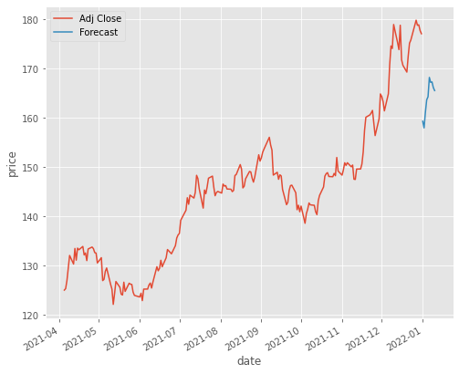

```python
clfreg = LinearRegression(n_jobs=-1)
clfreg.fit(x_train, y_train)
score = clfreg.score(x_test, y_test)
forecast_set = clfreg.predict(x_lately)
datareg['Forecast'] = np.nan
last_date = datareg.iloc[-1].name
last_unix =last_date
next_unix = last_unix + datetime.timedelta(days=1)

for i in forecast_set:
    next_date = next_unix
    next_unix = next_unix + datetime.timedelta(days=1)
    datareg.loc[next_date] = [
        np.nan for _ in range(len(datareg.columns)-1)]+[i]

datareg["Adj Close"].tail(200).plot()
datareg["Forecast"].tail(200).plot()
plt.legend(loc=2)
plt.xlabel('date')
plt.ylabel("price")
plt.show()
```